# Group 4 - Winter 2025 Predictive Analytics (DAMO-510-6)

- Carlos Borda (NF1003721)
- Renato Leiva (NF1000920)
- Mario Zamudio (NF1002499)

## Dataset Sources

```
https://toronto.weatherstats.ca/
https://data.torontopolice.on.ca/datasets/bc4c72a793014a55a674984ef175a6f3_0/explore?location=6.523481%2C-39.819624%2C2.63
```

### DataSet Description

- **OCC_DATE.1**- The date of the occurrence of the traffic collision.
- **Year** - The year in which the collision occurred.
- **NEIGHBOURHOOD_158** - The neighborhood where the traffic collision happened, with its corresponding ID.
- **avg_temperature** - The average temperature (likely in degrees Celsius) on the day of the collision.
- **0 or 1 snow** - A binary indicator (0 or 1) showing whether there was snowfall on the given day.
- **avg_wind_speed** - The average wind speed (likely in km/h) recorded on that day.
- **avg_visibility** - The average visibility (likely in meters) on the day of the collision.
- **snow** - The amount of snowfall (likely in cm) recorded on that day.
- **snow_on_ground** - The amount of snow accumulated on the ground (likely in cm).
- **Number of events** - The number of traffic collision events recorded on that day in the specified neighborhood.
- **Longitud** - The longitude coordinate of the location where the collision occurred.
- **Latitude** - The latitude coordinate of the location where the collision occurred.
- **AVG_Precipitation** - The average precipitation (likely in mm) recorded on that day.
- **Day_of_the_week** - The day of the week (e.g., Monday, Tuesday, etc.) when the collision occurred

## DataSet Preparation

### Imports and Definitions

```python
import pandas as pd
import numpy as np
import matplotlib.pyplot as plt
import seaborn as sns
import warnings
import joblib
import statsmodels.api as sm
import scipy.stats as stats

import sklearn
from sklearn import metrics
from sklearn.metrics import mean_absolute_error

from sklearn.model_selection import train_test_split
from sklearn.preprocessing import StandardScaler, LabelEncoder
from sklearn.ensemble import RandomForestRegressor, GradientBoostingRegressor  # Updated
from sklearn.linear_model import LinearRegression
from sklearn.svm import SVR
from sklearn.metrics import mean_squared_error, r2_score
```

### Load and Initial configurations

- Suppresses unnecessary warnings.
- Loads traffic collision data from a CSV file.
- Inspects the dataset’s structure and data types.
- Cleans column names for easier usage.
- Displays a preview of the dataset.

```python
# Ignore specific warnings
warnings.filterwarnings("ignore", category=UserWarning)
warnings.filterwarnings("ignore", category=FutureWarning)

# Load the dataset
df = pd.read_csv("Events by Day Traffic Colission Toronto5.csv")

# check the data types of the data
df.info()

# Rename columns to remove spaces and convert to uppercase
df.columns = [col.strip().upper().replace(" ", "_") for col in df.columns]

# Print data sample
df
```

```
<class 'pandas.core.frame.DataFrame'>
RangeIndex: 75089 entries, 0 to 75088
Data columns (total 14 columns):
 #   Column              Non-Null Count  Dtype
---  ------              --------------  -----
 0   OCC_DATE.1          75089 non-null  object
 1   Year                75089 non-null  int64
 2   NEIGHBOURHOOD_158   75089 non-null  object
 3   avg_temperature     75089 non-null  float64
 4   0 or 1 snow         75089 non-null  int64
 5   avg_wind_speed      75089 non-null  float64
 6   avg_visibility      75089 non-null  int64
 7   snow                74708 non-null  float64
 8   snow_on_ground      75089 non-null  int64
 9    Number of events   75089 non-null  int64
 10  Longitud            75089 non-null  float64
 11  Latitude            75089 non-null  float64
 12  AVG_Precipitation   74862 non-null  float64
 13  Day_of_the_week     75089 non-null  object
dtypes: float64(6), int64(5), object(3)
memory usage: 8.0+ MB
```

|  | OCC_DATE.1 | YEAR | NEIGHBOURHOOD_158 | AVG_TEMPERATURE | 0_OR_1_SNOW | AVG_WIND_SPEED | AVG_VISIBILITY | SNOW | SNOW_ON_GROUND | NUMBER_OF_EVENTS | LONGITUD | LATITUDE | AVG_PRECIPITATION | DAY_OF_THE_WEEK |
| --- | --- | --- | --- | --- | --- | --- | --- | --- | --- | --- | --- | --- | --- | --- |
| 0 | 2022-01-01 | 2022 | St Lawrence-East Bayfront-The Islands (166) | 0.64 | 1 | 18.0 | 12250 | 3.0 | 3 | 5 | -79.375417 | 43.643198 | 2.4 | Saturday |
| 1 | 2022-01-01 | 2022 | Alderwood (20) | 0.64 | 1 | 18.0 | 12250 | 3.0 | 3 | 1 | -79.548316 | 43.609070 | 2.4 | Saturday |
| 2 | 2022-01-01 | 2022 | South Riverdale (70) | 0.64 | 1 | 18.0 | 12250 | 3.0 | 3 | 2 | -79.337223 | 43.662688 | 2.4 | Saturday |
| 3 | 2022-01-01 | 2022 | Kingsview Village-The Westway (6) | 0.64 | 1 | 18.0 | 12250 | 3.0 | 3 | 1 | -79.552151 | 43.695790 | 2.4 | Saturday |
| 4 | 2022-01-01 | 2022 | Yonge-St.Clair (97) | 0.64 | 1 | 18.0 | 12250 | 3.0 | 3 | 1 | -79.401513 | 43.686701 | 2.4 | Saturday |
| ... | ... | ... | ... | ... | ... | ... | ... | ... | ... | ... | ... | ... | ... | ... |
| 75084 | 2024-06-30 | 2024 | Englemount-Lawrence (32) | 17.70 | 0 | 26.5 | 15250 | 0.0 | 0 | 1 | -79.434161 | 43.729214 | 0.6 | Sunday |
| 75085 | 2024-06-30 | 2024 | Danforth (66) | 17.70 | 0 | 26.5 | 15250 | 0.0 | 0 | 2 | -79.325398 | 43.682977 | 0.6 | Sunday |
| 75086 | 2024-06-30 | 2024 | Lansing-Westgate (38) | 17.70 | 0 | 26.5 | 15250 | 0.0 | 0 | 1 | -79.432825 | 43.756630 | 0.6 | Sunday |
| 75087 | 2024-06-30 | 2024 | Kingsview Village-The Westway (6) | 17.70 | 0 | 26.5 | 15250 | 0.0 | 0 | 1 | -79.545151 | 43.697425 | 0.6 | Sunday |
| 75088 | 2024-06-30 | 2024 | Yorkdale-Glen Park (31) | 17.70 | 0 | 26.5 | 15250 | 0.0 | 0 | 1 | -79.451306 | 43.723657 | 0.6 | Sunday |

75089 rows × 14 columns

### Data Cleaning

- Removes unnecessary or redundant columns (e.g., correlated weather variables, date-related columns).
- Identifies missing values before cleaning.
- Replaces missing snowfall (SNOW) values with 0 instead of dropping them.
- Deletes all other rows with missing values to ensure a complete dataset.
- Confirms that missing values are eliminated after cleaning.

```python
# Remove highly correlated variable PRECIPITATION
if 'AVG_PRECIPITATION' in df.columns:
    df.drop(columns=['AVG_PRECIPITATION'], inplace=True)
if 'YEAR' in df.columns:
    df.drop(columns=['YEAR'], inplace=True)
if 'OCC_DATE.1' in df.columns:
    df.drop(columns=['OCC_DATE.1'], inplace=True)
if 'DAY_OF_THE_WEEK' in df.columns:
    df.drop(columns=['DAY_OF_THE_WEEK'], inplace=True)
if 'NEIGHBOURHOOD_158' in df.columns:
    df.drop(columns=['NEIGHBOURHOOD_158'], inplace=True)

# Identify columns with missing values and remove rows with missing values
missing_values = df.isnull().sum()
columns_with_na = missing_values[missing_values > 0].index.tolist()
print("Columns with missing values before cleaning:", columns_with_na)
# Reemplazar valores nulos en la columna SNOW con 0
df['SNOW'].fillna(0, inplace=True)

df.dropna(inplace=True)
missing_values = df.isnull().sum()
columns_with_na = missing_values[missing_values > 0].index.tolist()
print("Columns with missing values after cleaning:", columns_with_na)
```

```
Columns with missing values before cleaning: ['SNOW']
Columns with missing values after cleaning: []
```

## Data Exploration

### Dataset description

- count → Number of non-null values.
- mean → Average of the values.
- std → Standard deviation (spread of the data).
- min → Minimum value.
- 25% (Q1) → First quartile (25% of data is below this value).
- 50% (median, Q2) → Middle value of the dataset.
- 75% (Q3) → Third quartile (75% of data is below this value).
- max → Maximum value.

#### Use Cases

Identify outliers (e.g., very high max values). Check data distribution (e.g., if mean ≠ median, the data may be skewed). Verify missing values (if count is lower than expected).

```python
print(df.describe())
```

```
       AVG_TEMPERATURE   0_OR_1_SNOW  AVG_WIND_SPEED  AVG_VISIBILITY  \
count     75089.000000  75089.000000    75089.000000    75089.000000
mean          9.396603      0.087217       16.551332    20095.814833
std          10.068853      0.282154        6.417941     4634.173968
min         -17.100000      0.000000        5.000000     3200.000000
25%           1.250000      0.000000       11.500000    15250.000000
50%           9.600000      0.000000       15.500000    21700.000000
75%          18.450000      0.000000       20.500000    24100.000000
max          28.650000      1.000000       47.000000    28150.000000

               SNOW  SNOW_ON_GROUND  NUMBER_OF_EVENTS      LONGITUD  \
count  75089.000000    75089.000000      75089.000000  75089.000000
mean       0.398514        1.420967          1.787159    -79.394091
std        1.934940        4.330962          1.213243      0.100299
min        0.000000        0.000000          1.000000    -79.639247
25%        0.000000        0.000000          1.000000    -79.466036
50%        0.000000        0.000000          1.000000    -79.397319
75%        0.000000        0.000000          2.000000    -79.324371
max       29.000000       32.000000         29.000000    -79.122044

           LATITUDE
count  75089.000000
mean      43.710761
std        0.053506
min       43.586487
25%       43.665873
50%       43.706910
75%       43.757230
max       43.844027
```

### Basic Visualizations

- Creates histograms for up to 12 numerical columns.
- Uses Seaborn’s histplot to visualize the distribution of each variable.
- Includes a KDE curve for a smoothed density estimate.
- Organizes charts in a 4x3 grid for readability.
- Helps identify skewness, normality, and outliers in the dataset.

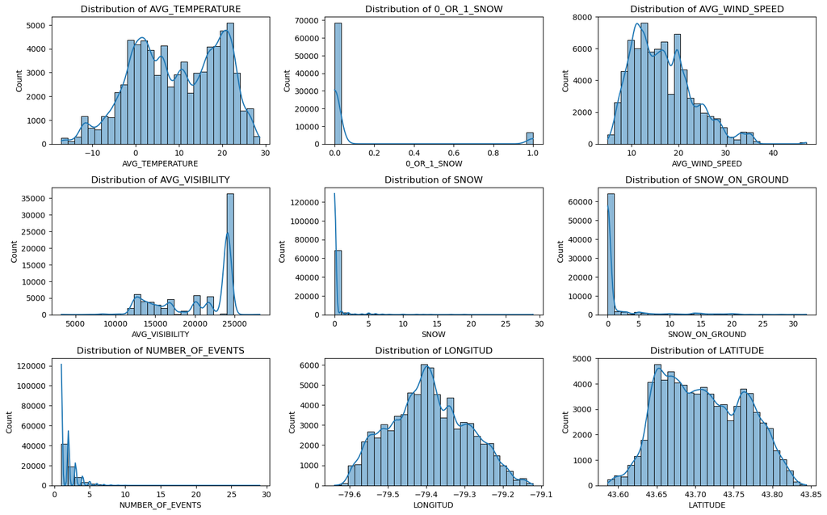

```python
# Visualization of histograms to validate variable distribution
numeric_columns = df.select_dtypes(include=['number']).columns
plt.figure(figsize=(15, 12))
for i, col in enumerate(numeric_columns[:12]):
    plt.subplot(4, 3, i + 1)
    sns.histplot(df[col], kde=True, bins=30)
    plt.title(f'Distribution of {col}')
plt.tight_layout()
plt.show()
```

### Correlation Analysis

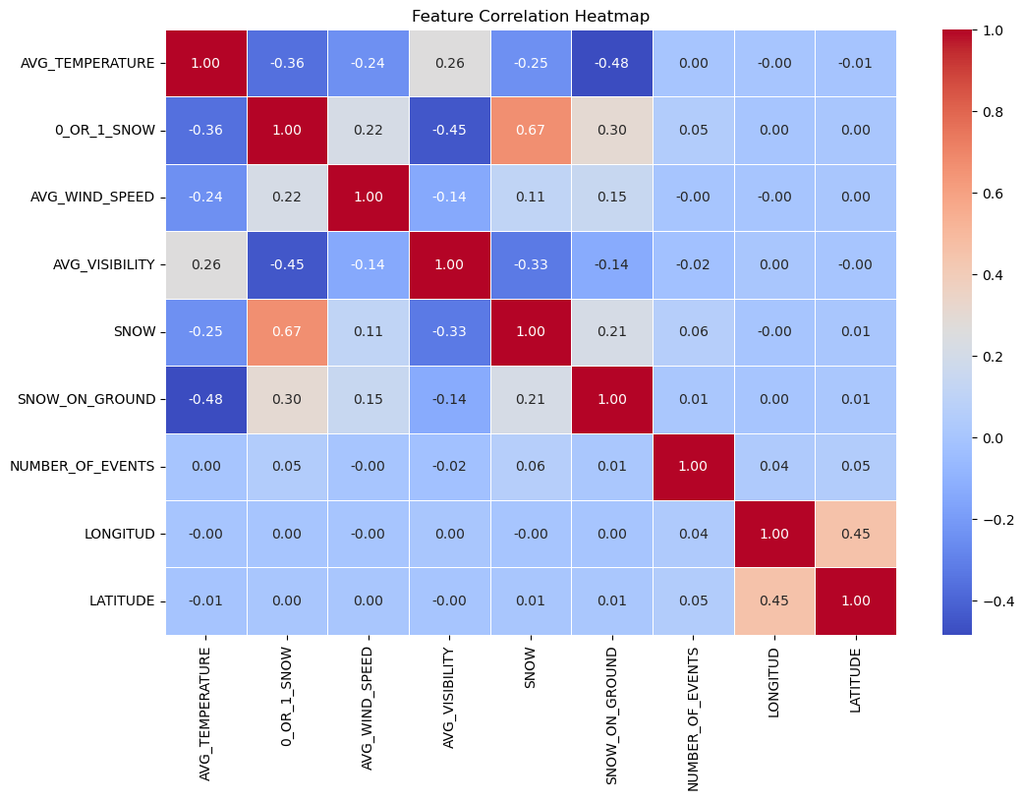

```python
# Check correlation between variables and generate a heatmap
numeric_df = df.select_dtypes(include=['number']).dropna()
if not numeric_df.empty:
    plt.figure(figsize=(12,8))
    sns.heatmap(numeric_df.corr(), annot=True, fmt='.2f', cmap='coolwarm', linewidths=0.5)
    plt.title("Feature Correlation Heatmap")
    plt.show()
```

### QQ Plots

- Selects numerical columns for normality testing.
- Generates Q-Q plots to visually check normality.
- Applies the Shapiro-Wilk test for a statistical normality check.
- Prints results indicating whether each column follows a normal distribution.

#### Use Cases

Identifying Normal vs. Non-Normal Data (important for choosing statistical tests or ML models). Detecting Skewness & Outliers. Preprocessing Decisions (e.g., applying log transformations if data is non-normal).

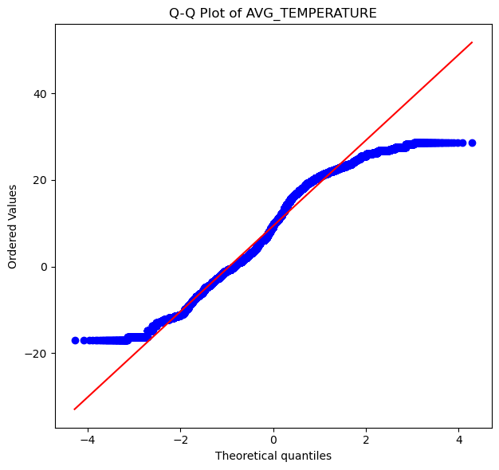

```
Shapiro-Wilk Test for AVG_TEMPERATURE:
Statistic: 0.968, p-value: 0.000
The data for 'AVG_TEMPERATURE' likely does not come from a normal distribution.
---
```

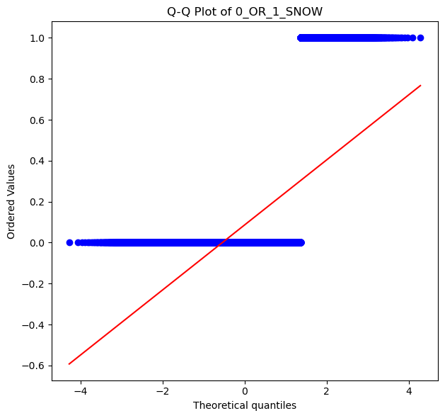

```
Shapiro-Wilk Test for 0_OR_1_SNOW:
Statistic: 0.316, p-value: 0.000
The data for '0_OR_1_SNOW' likely does not come from a normal distribution.
---
```

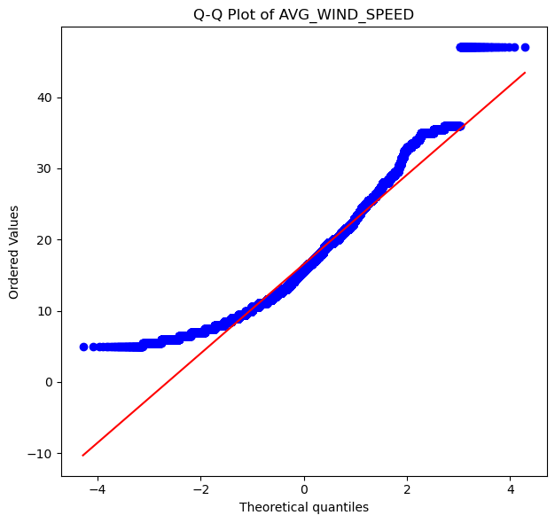

```
Shapiro-Wilk Test for AVG_WIND_SPEED:
Statistic: 0.956, p-value: 0.000
The data for 'AVG_WIND_SPEED' likely does not come from a normal distribution.
---
```

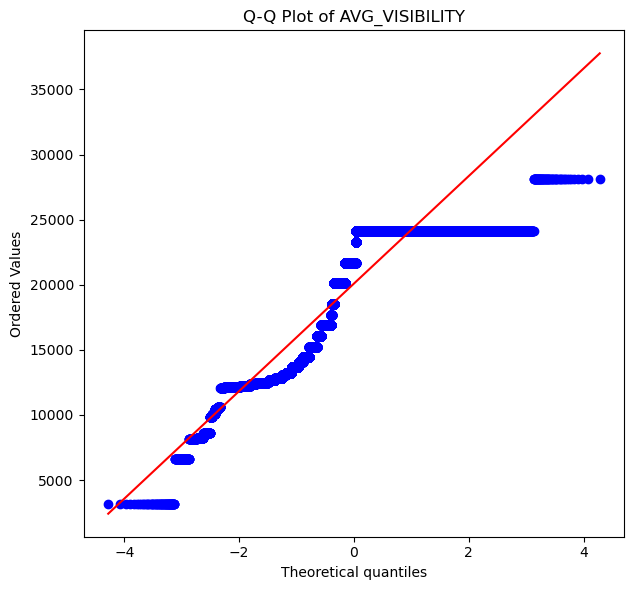

```
Shapiro-Wilk Test for AVG_VISIBILITY:
Statistic: 0.793, p-value: 0.000
The data for 'AVG_VISIBILITY' likely does not come from a normal distribution.
---
```

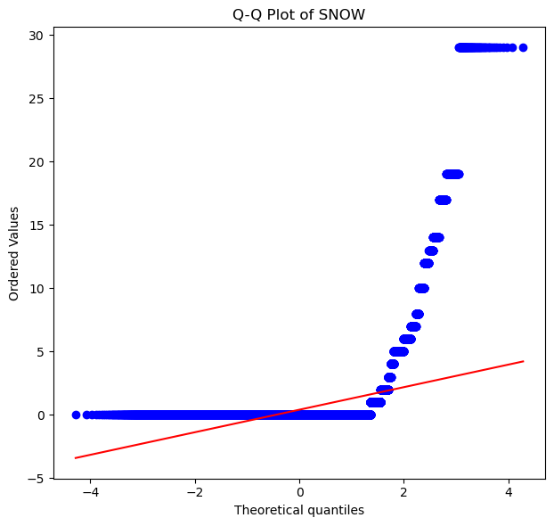

```
Shapiro-Wilk Test for SNOW:
Statistic: 0.212, p-value: 0.000
The data for 'SNOW' likely does not come from a normal distribution.
---
```

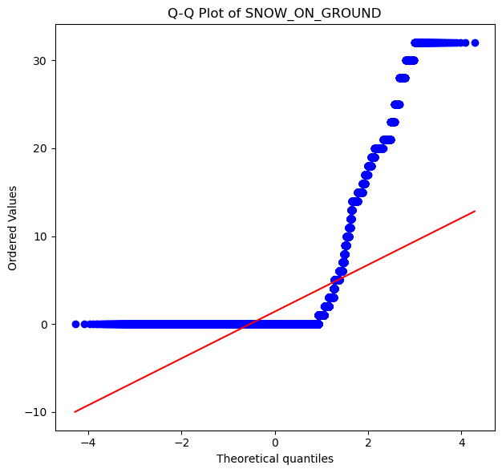

```
Shapiro-Wilk Test for SNOW_ON_GROUND:
Statistic: 0.378, p-value: 0.000
The data for 'SNOW_ON_GROUND' likely does not come from a normal distribution.
---
```

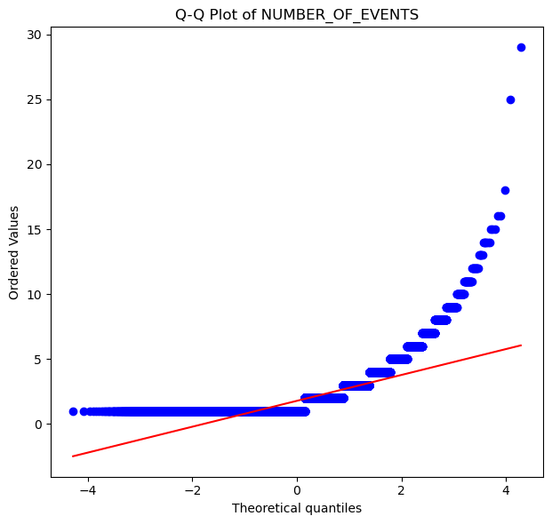

```
Shapiro-Wilk Test for NUMBER_OF_EVENTS:
Statistic: 0.674, p-value: 0.000
The data for 'NUMBER_OF_EVENTS' likely does not come from a normal distribution.
---
```

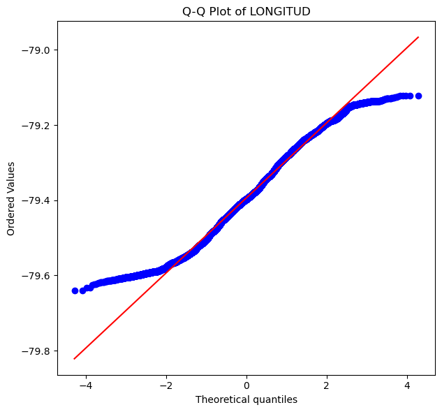

```
Shapiro-Wilk Test for LONGITUD:
Statistic: 0.990, p-value: 0.000
The data for 'LONGITUD' likely does not come from a normal distribution.
---
```

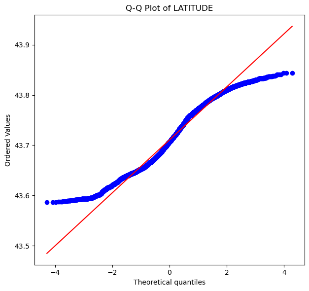

```
Shapiro-Wilk Test for LATITUDE:
Statistic: 0.974, p-value: 0.000
The data for 'LATITUDE' likely does not come from a normal distribution.
---
```

```python
# Visualize distributions of numerical features with normality checks
numerical_cols = df.select_dtypes(include=['number']).columns

for col in numerical_cols:
    plt.figure(figsize=(12, 6))

    # Q-Q plot
    plt.subplot(1, 2, 2)
    stats.probplot(df[col], dist="norm", plot=plt)
    plt.title(f'Q-Q Plot of {col}')
    plt.tight_layout()
    plt.show()

    # Shapiro-Wilk test for normality
    shapiro_test = stats.shapiro(df[col].dropna()) # Drop NA values for the test
    print(f"Shapiro-Wilk Test for {col}:")
    print(f"Statistic: {shapiro_test.statistic:.3f}, p-value: {shapiro_test.pvalue:.3f}")
    if shapiro_test.pvalue > 0.05:
        print(f"The data for '{col}' likely comes from a normal distribution.")
    else:
        print(f"The data for '{col}' likely does not come from a normal distribution.")
    print("---")
```

### Regression Analysis

- Defines independent (X) and dependent (y) variables.
- Ensures data alignment by keeping only matching rows.
- Adds a constant for regression.
- Performs multiple linear regression using statsmodels.
- Handles cases where there are not enough data points.

#### Use Cases

Understanding the impact of multiple factors on NUMBER_OF_EVENTS. Identifying significant predictors using p-values. Assessing the model’s performance via R-squared. Optimizing feature selection to improve prediction accuracy.

```python
# Define variable independents X and variable dependent y
y = pd.to_numeric(df['NUMBER_OF_EVENTS'], errors='coerce')
X = df.drop(columns=['NUMBER_OF_EVENTS'], errors='ignore')

# Align the values
X, y = X.align(y, join='inner', axis=0)

# Multiple Regression Analysis
X_const = sm.add_constant(X)
if X_const.shape[0] > X_const.shape[1]:
    model = sm.OLS(y, X_const).fit()
    print(model.summary())
else:
    print("Not enough data points for multiple regression analysis.")
```

```
                            OLS Regression Results
==============================================================================
Dep. Variable:       NUMBER_OF_EVENTS   R-squared:                       0.007
Model:                            OLS   Adj. R-squared:                  0.007
Method:                 Least Squares   F-statistic:                     63.94
Date:                Mon, 10 Mar 2025   Prob (F-statistic):          5.64e-105
Time:                        20:30:06   Log-Likelihood:            -1.2081e+05
No. Observations:               75089   AIC:                         2.416e+05
Df Residuals:                   75080   BIC:                         2.417e+05
Df Model:                           8
Covariance Type:            nonrobust
===================================================================================
                      coef    std err          t      P>|t|      [0.025      0.975]
-----------------------------------------------------------------------------------
const             -20.2314      6.785     -2.982      0.003     -33.531      -6.932
AVG_TEMPERATURE     0.0030      0.001      5.610      0.000       0.002       0.004
0_OR_1_SNOW         0.0681      0.023      2.941      0.003       0.023       0.113
AVG_WIND_SPEED     -0.0011      0.001     -1.586      0.113      -0.003       0.000
AVG_VISIBILITY  -1.274e-06   1.08e-06     -1.183      0.237   -3.38e-06    8.36e-07
SNOW                0.0337      0.003     10.999      0.000       0.028       0.040
SNOW_ON_GROUND      0.0025      0.001      2.117      0.034       0.000       0.005
LONGITUD            0.2118      0.049      4.292      0.000       0.115       0.309
LATITUDE            0.8883      0.093      9.603      0.000       0.707       1.070
==============================================================================
Omnibus:                    45208.571   Durbin-Watson:                   1.686
Prob(Omnibus):                  0.000   Jarque-Bera (JB):           726301.185
Skew:                           2.613   Prob(JB):                         0.00
Kurtosis:                      17.312   Cond. No.                     3.17e+07
==============================================================================

Notes:
[1] Standard Errors assume that the covariance matrix of the errors is correctly specified.
[2] The condition number is large, 3.17e+07. This might indicate that there are
strong multicollinearity or other numerical problems.
```

## Model Preparation and Training

### Splitting DataSet

- Ensures that the model is trained on one part of the data (X_train, y_train)
- Tests the model’s performance on unseen data (X_test, y_test)
- Prevents overfitting, ensuring that the model generalizes well to new data
- Uses a random seed (random_state=42) to make the split consistent across runs

#### Use Cases

Machine Learning Model Training (e.g., regression, classification). Model Evaluation using testing data. Hyperparameter Tuning with validation sets.

```python
# Splitting into training and testing sets
X_train, X_test, y_train, y_test = train_test_split(X, y, test_size=0.2, random_state=42)
```

### Defining Models to Train and Test

- Defines three different machine learning models (Random Forest, Gradient Boosting, Linear Regression).
- Uses optimized hyperparameters for better performance.
- Prepares for model training and evaluation.
- Initializes an empty results dictionary to store model performance metrics.

```python
# Training multiple models with optimized parameters
models = {
    "Random Forest": RandomForestRegressor(n_estimators=200, max_depth=10, random_state=42),
    "Gradient Boosting": GradientBoostingRegressor(n_estimators=200, learning_rate=0.1, max_depth=3, random_state=42),
    "Linear Regression": LinearRegression()
}
results = {}
```

### Function to evaluate the Models

- Computes regression metrics (MSE, RMSE, R²) to evaluate performance.
- Creates a scatter plot to visualize predicted vs. actual values.
- Discretizes continuous predictions into bins to analyze accuracy.
- Generates a confusion matrix for regression by comparing bins.
- Uses a heatmap to display the confusion matrix.

#### Use Cases

Evaluating regression models to check their predictive performance. Visualizing prediction errors (scatter plot, confusion matrix). Comparing models to see which has the lowest error.

```python
def evaluate_model(model, X_test, y_test):
    num_bins=4
    y_pred = model.predict(X_test)

    # Regression metrics
    mse = mean_squared_error(y_test, y_pred)
    rmse = np.sqrt(mse)
    r2 = r2_score(y_test, y_pred)

    print(f'Mean Squared Error (MSE): {mse:.4f}')
    print(f'Root Mean Squared Error (RMSE): {rmse:.4f}')
    print(f'R-squared (R2): {r2:.4f}')

    # ... (Optional: Scatter plot of predicted vs. actual values) ...
    plt.figure(figsize=(8, 6))
    plt.scatter(y_test, y_pred)
    plt.xlabel("Actual Values")
    plt.ylabel("Predicted Values")
    plt.title("Actual vs. Predicted Values")
    plt.show()

    # Import confusion_matrix if not already imported
    from sklearn.metrics import confusion_matrix

    # Discretize predictions and actual values into bins
    # Added duplicates='drop' to handle non-unique bin edges
    y_test_bins = pd.qcut(y_test, q=num_bins, labels=False, duplicates='drop')
    y_pred_bins = pd.qcut(y_pred, q=num_bins, labels=False, duplicates='drop')


    # Create confusion matrix
    cm = confusion_matrix(y_test_bins, y_pred_bins)

    # Plotting the confusion matrix
    plt.figure(figsize=(8, 6))
    sns.heatmap(cm, annot=True, fmt="d", cmap="Blues")
    plt.xlabel("Predicted Bins")
    plt.ylabel("Actual Bins")
    plt.title("Confusion Matrix for Regression")
    plt.show()
```

### Model Evaluation

- Trains multiple models on the training dataset.
- Evaluates each model using regression metrics, scatter plots, and a confusion matrix.
- Saves each trained model as a .pkl file.
- Stores the RMSE for each model to compare their performance.

#### Use Cases

Comparing different models (Random Forest vs. Gradient Boosting vs. Linear Regression). Selecting the best model based on RMSE. Saving trained models to use later without retraining.

```
Random Forest Model Evaluation
Mean Squared Error (MSE): 0.9550
Root Mean Squared Error (RMSE): 0.9772
R-squared (R2): 0.3503
```

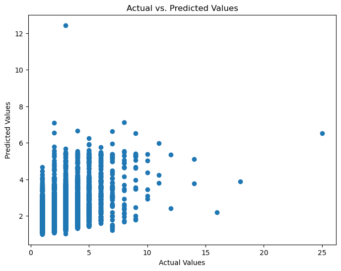

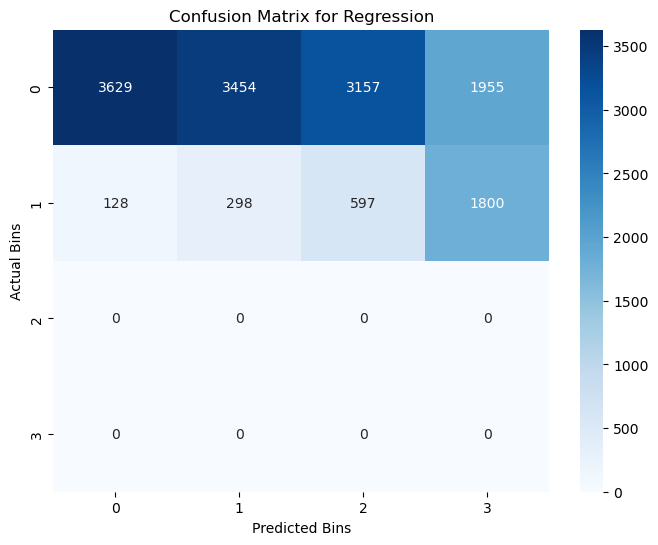

```
Gradient Boosting Model Evaluation
Mean Squared Error (MSE): 1.1241
Root Mean Squared Error (RMSE): 1.0602
R-squared (R2): 0.2353
```

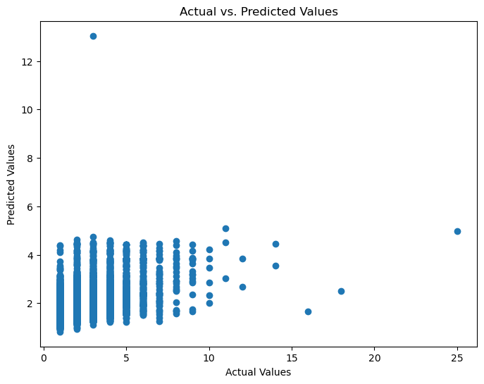

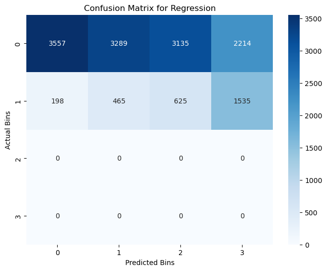

```
Linear Regression Model Evaluation
Mean Squared Error (MSE): 1.4583
Root Mean Squared Error (RMSE): 1.2076
R-squared (R2): 0.0080
```

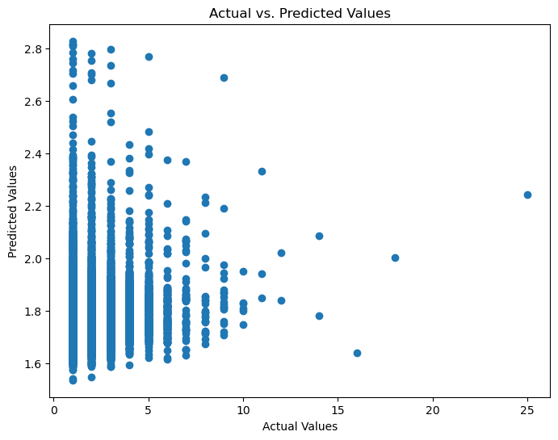

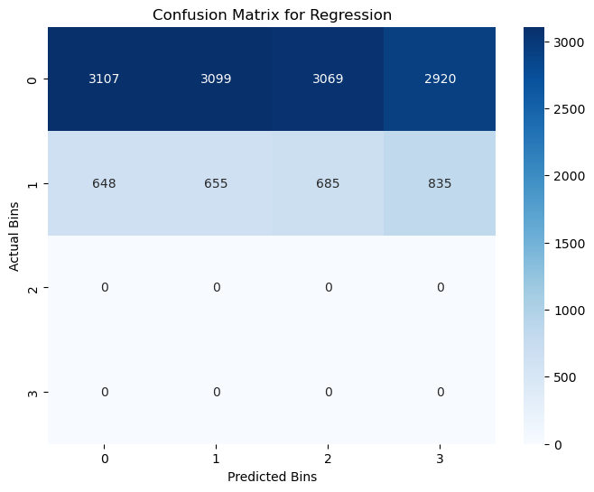

```python
# Evaluation Models
for name, model in models.items():
    # Changed line below: Pass X_train and y_train as arguments to fit
    model.fit(X_train, y_train)
    print(f"\n{name} Model Evaluation")
    evaluate_model(model, X_test, y_test)
    joblib.dump(model, f'{name.replace(" ", "_").lower()}_model.pkl')
    results[name] = np.sqrt(mean_squared_error(y_test, model.predict(X_test))) # Store RMSE
```

### Model Comparition

- Creates a bar chart comparing RMSE values for different models.
- Uses different colors for better visualization.
- Labels axes & rotates model names for clarity.
- Helps identify the best model (the one with the lowest RMSE).

#### Use Cases

Selecting the best model based on RMSE. Visualizing model performance differences. Determining whether additional tuning is needed.

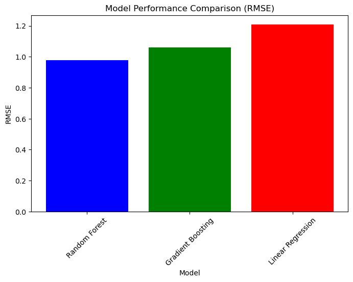

```python
# 20. Model comparison
plt.figure(figsize=(8,5))
plt.bar(results.keys(), results.values(), color=['blue', 'green', 'red', 'purple', 'gray'])
plt.xlabel("Model")
plt.ylabel("RMSE") # Change y-axis label
plt.title("Model Performance Comparison (RMSE)") # Update title
plt.xticks(rotation=45)
plt.show()
```

## Using the Models

- Randomly selects 5 test samples from X_test.
- Prints the selected sample data for verification.
- Loads each trained model from its saved .pkl file.
- Generates and prints predictions from each model.

### Use Cases

Testing model predictions on unseen data. Comparing different model outputs on the same sample. Verifying that saved models work correctly after being loaded.

```python
# Test with sample input data
random_indices = np.random.choice(len(X_test), 5, replace=False)
sample_data = X_test.iloc[random_indices]

print("Sample input data:")
print(sample_data)

for name, model in models.items():
    loaded_model = joblib.load(f'{name.replace(" ", "_").lower()}_model.pkl')
    predictions = loaded_model.predict(sample_data)
    print(f"\nPredictions from {name}:", predictions)
```

```
Sample input data:
       AVG_TEMPERATURE  0_OR_1_SNOW  AVG_WIND_SPEED  AVG_VISIBILITY  SNOW  \
10817            17.70            0            13.5           24100   0.0
17820            21.70            0            11.0           20100   0.0
9311             10.70            0            16.5           24100   0.0
34908             2.15            0            28.0           24100   0.0
1295            -13.75            0            18.0           24100   0.0

       SNOW_ON_GROUND   LONGITUD   LATITUDE
10817               0 -79.449384  43.676476
17820               0 -79.401234  43.660649
9311                0 -79.297861  43.776520
34908               1 -79.560010  43.646340
1295               25 -79.459948  43.674131

Predictions from Random Forest: [1.61907005 1.6215865  1.67272156 1.13491531 1.6276811 ]

Predictions from Gradient Boosting: [1.56582782 1.59356405 2.44570647 1.27388694 1.64345978]

Predictions from Linear Regression: [1.74406004 1.76640872 1.84151488 1.62656155 1.68973751]
```